# GarciaFinal728

### Adding Data to World sf File

First, we are going to read in the csv file of the desired dataset. The one I have chosen for this is ‘urbanland.csv’ that shows urban land coverage at the country level, as well as exploring what is within the csv file using head()

```r
library(pacman)

#Reads in csv file for landcover
urban<- read.csv("urbanland.csv", stringsAsFactors = FALSE)

head(urban)
```

```
##   ï..Country.Name Country.Code       X1990       X2000       X2010
## 1           Aruba          ABW    172.8477    172.8477    172.8477
## 2     Afghanistan          AFG          NA          NA          NA
## 3          Angola          AGO   1427.0295   1427.0295   1427.0295
## 4         Albania          ALB   1689.4038   1689.4038   1689.4038
## 5         Andorra          AND          NA          NA          NA
## 6      Arab World          ARB 193254.6571 193254.6571 193254.6571
```

Though I had to clean up the file itself within excel. There are only 3 years worth of data. This tutorial is going to focus on the 2010 data. What we are going to do next is to separate the countries within the csv file from the countries that appear in the urban_agglomeration dataset for the year of 2010. The code will show a red ‘x’ next to the line of code where we filter out the countries because of the character associated with the feature. This is not an issue and will not throw any problems with the code, but it’s something that can also mean that there is a problem with that line so please check it before running it through.

```r
library(pacman)

#Filter of countries that are highest populated
urb_name <- urban %>%
  filter(urban$ï..Country.Name %in% c("Argentina","Bangladesh", "Brazil", "China", "Colombia", "Democratic Republic of the Congo", "Egypt", "France", "India", "Indonesia", "Japan", "Mexico", "Nigeria", "Pakistan", "Philippines", "Russian Federation", "Turkey", "United States" ))

#Checking structure of the new variable
str(urb_name)
```

```
## 'data.frame':    17 obs. of  5 variables:
##  $ ï..Country.Name: chr  "Argentina" "Bangladesh" "Brazil" "China" ...
##  $ Country.Code   : chr  "ARG" "BGD" "BRA" "CHN" ...
##  $ X1990          : num  55032 11125 134981 380679 9062 ...
##  $ X2000          : num  55032 11125 134981 380679 9062 ...
##  $ X2010          : num  55032 11125 134981 380679 9062 ...
```

Now that we have our data organized into the countries we want; we are going to join this data into the ‘world’ dataset so we can properly display the data on a map. Using the ‘left_join’ method, we have joined the data from our landcover dataset to the world dataset within R. This is a technique used when you want to join two datasets together, this is very important in this project and almost every project that deals with two datasets. It requires that both datasets contain a similar field that can be joined together. The field that I joined my two datasets together by is ‘name_long’ and ‘ï..Country.Name’. These fields being ones that contain the names of the countries within each dataset.

```r
library(pacman)

#Joining urban landcover data to world dataset
nworld<- left_join(world, urb_name, by = c("name_long" = "ï..Country.Name"))

str(nworld)
```

```
## Classes 'sf', 'tbl_df', 'tbl' and 'data.frame':  177 obs. of  15 variables:
##  $ iso_a2      : chr  "FJ" "TZ" "EH" "CA" ...
##  $ name_long   : chr  "Fiji" "Tanzania" "Western Sahara" "Canada" ...
##  $ continent   : chr  "Oceania" "Africa" "Africa" "North America" ...
##  $ region_un   : chr  "Oceania" "Africa" "Africa" "Americas" ...
##  $ subregion   : chr  "Melanesia" "Eastern Africa" "Northern Africa" "Northern America" ...
##  $ type        : chr  "Sovereign country" "Sovereign country" "Indeterminate" "Sovereign country" ...
##  $ area_km2    : num  19290 932746 96271 10036043 9510744 ...
##  $ pop         : num  8.86e+05 5.22e+07 NA 3.55e+07 3.19e+08 ...
##  $ lifeExp     : num  70 64.2 NA 82 78.8 ...
##  $ gdpPercap   : num  8222 2402 NA 43079 51922 ...
##  $ geom        :sfc_MULTIPOLYGON of length 177; first list element: List of 3
##   ..$ :List of 1
##   .. ..$ : num [1:8, 1:2] 180 180 179 179 179 ...
##   ..$ :List of 1
##   .. ..$ : num [1:9, 1:2] 178 178 179 179 178 ...
##   ..$ :List of 1
##   .. ..$ : num [1:5, 1:2] -180 -180 -180 -180 -180 ...
##   ..- attr(*, "class")= chr  "XY" "MULTIPOLYGON" "sfg"
##  $ Country.Code: chr  NA NA NA NA ...
##  $ X1990       : num  NA NA NA NA 802054 ...
##  $ X2000       : num  NA NA NA NA 802054 ...
##  $ X2010       : num  NA NA NA NA 802054 ...
##  - attr(*, "sf_column")= chr "geom"
##  - attr(*, "agr")= Factor w/ 3 levels "constant","aggregate",..: NA NA NA NA NA NA NA NA NA NA ...
##   ..- attr(*, "names")= chr  "iso_a2" "name_long" "continent" "region_un" ...
```

As we can see from checking the structure of the dataset that we successfully joined the dataset together with the world sf file. Now we display it! The usage for ggplot helps with the visualization of the data as compared to using just the plot method. This method of visualization adds more ease in displaying the data as well as making it more visually pleasing. As the plot() method just gives us basic plots, ggplot() gives us more design options for not only the map but for the labels. This method lets us change the whole theme of the map, and the ability to subset more data within the map with ease. This method was chosen because of the ease of access and methods used to add detail to the maps.

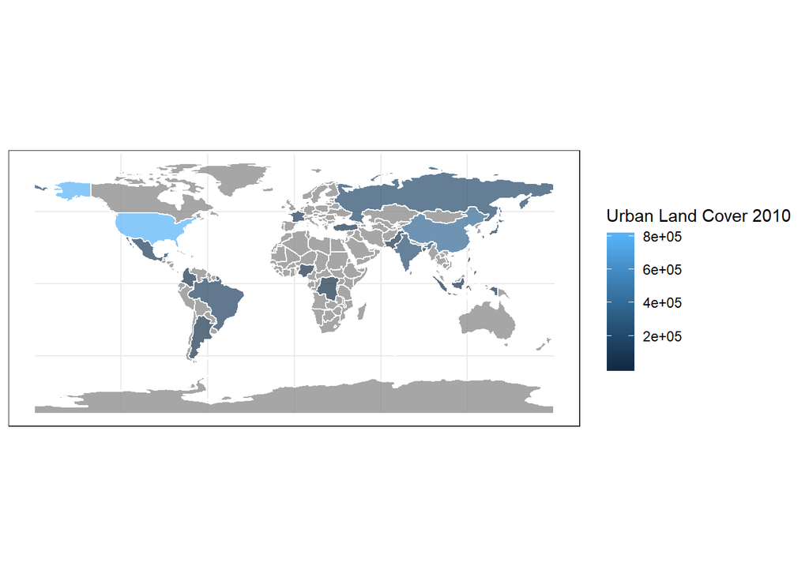

```r
library(pacman)

#Creation of map that displays each country with urban landcover
ggplot() +
  geom_sf(data = nworld, aes(fill = X2010), alpha = 0.7, col = "white") +
  labs(fill= "Urban Land Cover 2010") +
  theme_bw()
```